# Open archaeology, open source?

Collaborative practices in an emerging community of archaeological software engineers

Authors

Affiliations

[Zack Batist](https://zackbatist.info)

Faculty of Information, University of Toronto

[Joe Roe](https://joeroe.io)

Institute of Archaeological Sciences, University of Bern

Published

September 20, 2023

Abstract

Surveying the first quarter-century of computer applications in archaeology, Scollar (1999) lamented that the field relied almost exclusively on “hand-me-down” tools repurposed from other disciplines. 25 years later, this is no longer the case: computational archaeologists often find themselves practicing the dual roles of data analyst and research software engineer (Baxter et al. 2012), developing and applying new tools that are tailored specifically to archaeological problems and archaeological methods. Though this trend can be traced to the very earliest days of the field (Cowgill 1967), its most recent manifestation is distinguished by its apparently embrace of practices from free and open source software (FOSS). Most prominently, since around 2015, there has been a rapid uptake of workflow tools designed for open source development communities, such as the version control system `git` and associated online source code management platforms (e.g. GitHub, GitLab). These tools facilitate collaboration among developers and users of FOSS software using patterns that can diverge quite radically from conventional scholarly norms (Tennant et al. 2020).

In this paper, we investigate modes of collaboration in this emerging community of practice using open-archaeo (https://open-archaeo.info/), a curated list of 500+ active open projects in archaeology, augmented where available with data on their activity on GitHub. We apply network analysis to map the networks of collaboration that have emerged among archaeologists using GitHub, and conduct a quantitative exploratory analysis to characterize the nature and intensity of these collaborations. Our results show an uneven adoption of open source collaborative practices beyond the basic use of `git` as a version control system and GitHub to host source code. A majority of repositories have 1–3 contributors, with only a few projects distinguished by an active and diverse developer base. More community-oriented features, such as GitHub’s ‘issues’ and ‘comments’, are used in only a minority of repositories. Preliminary findings from ongoing work also shows how collaborative behaviours vary across different subcommunities. By analyzing interactions among archaeologists using the GitHub platform, including the ways they contribute to collective code bases, we demonstrate how archaeological software engineering is beginning to foster new kinds of collaborative commitments that blend open source protocols, DIY work ethic, conventional forms of scholarly communication, and cultural practices unique to archaeology.

# 1 Introduction

In their seminal vision for open archaeology, Beck and Neylon (2012, 480–81) identified the movement as comprising a series of principles and practices “predicated on promoting open redistribution and access to the data, processes and syntheses generated within the archaeological domain” with the aim of “maximizing transparency, reuse and engagement while maintaining professional probity”. Open archaeology therefore promotes more thoughtful scholarly communication practices, most notably in operations relating to publishing, data-sharing, education, and review processes. Archaeologists are also actively engaged in open source software development as means of sharing their research processes and creating tools and resources for general use.

The relationship between open science and open source is also complicated by rhetorical claims that have a questionable connection to how academics actually *do* open source. Does academic open source actually make research processes more transparent and improve research outcomes? Is it actually boosting efficiency by establishing a common store of knowledge and productive code? Is it actually helping to foster new globe-spanning connections and lead to novel research trajectories that would not otherwise come to pass? Basically, is it more than just uploading code and data files to the internet?

Despite hopeful aspirations espoused by open archaeology advocates (see Kansa, Whitcher Kansa, and Arbuckle 2014; Kintigh et al. 2015), these outcomes are not a given. We believe that these outcomes only actually arise in contexts where participants adhere to and are motivated by warrants, professional norms, and governance strategies that encourage these results. However, practical circumstances and systemic value regimes that frame what it means to work as an archaeologist presently inhibit the potential for radical transformation, even among open science’s most ardent supporters.

This article presents a survey of archaeological software development with two goals in mind:

1. we identify *what* kinds of software archaeologists are making;
2. and evaluate *how* archaeologists create these tools, with particular emphasis on practices of collaboration.

# 2 Open science and open source

## 2.1 Open source

Open source is a software development model that prioritizes transparent work processes. Initially driven by the idea that computer users should be free to understand and manipulate the software that they install on their computers (e.g., “free software”, as initially conceived by the Free Software Foundation), open source has become a means of collaborative software development (Kelty 2008: chapter 3, especially starting at page 99). By putting one’s code on the web without restriction on how it may be used or manipulated, this encourages creativity to flourish as people contribute to help improve the code base. Software thus emerges from the coordinated labour of worldwide volunteers, who shape the product according to the collective vision (Kelty 2008 on the emacs saga). An open code base may also be used to support alternative projects whose missions diverge from the original plan, and an entire project may be “forked”, or taken in a new direction if contributors are dissatisfied with how core developers run things.

Open source has traditionally been referred to as being based on meritocratic principles. A good test of whether a contribution should be included in a published software release is whether it is functional (Kelty 2008, 220). Moreover, with more eyes looking over a code base, it is easier to identify flaws with a contribution and flag potential bugs or security issues. This is all done in the spirit of producing functional code, and in ideal circumstances faulty contributions will be corrected before inclusion. Personal ego is minimized in favour of co-creating stable and functional outcomes (Coleman 2012; O’Neil 2009 on the debian saga).

However, this is not the same as saying that open source is completely anarchic or based on the “wisdom of crowds”. In fact, successful open source projects incorporate complex organizational structures, governance strategies, and forms or social mediation to help delegate and vet contributions made by distributed participants (O’Neil 2009). They rely on, rather than eschew, institutional support structures, in order to motivate work, keep volunteer maintainers involved, and generally ensure that the project can be sustained over the long-term. Open source is more than just putting your code online; to be successful, it requires participation in a social experience (Kelty 2008, Ratto dissertation and derived works).

In other words, as with many so-called “soft skills” that are crucial for academic professional development, additional competencies relating to the maintenance, management, and distribution of software, such as the ability to receive and implement feedback, set and stick with long-term goals, coordinate labour, document work practices, and collaborate with others, are grossly underappreciated factors that contribute to an open source project’s success.

We therefore consider open source to be a means of collaboration more than a means of transmitting information. It involves developing software as part of a group, developing consensus, and working with common purpose. Crucially, it also involves having a welcoming attitude, a sense of humility, and an understanding that one’s work may be appropriated and used in unanticipated ways.

## 2.2 Open science

The open science movement comprises a series of practices and principles intended to make research more accessible, transparent, and efficient. Although the concept of “open” is somewhat nebulous, in terms of its abstract definition and with regards to what real-world applications count as being open, one commonly-cited definition describes content that “can be freely used, modified, and shared by anyone for any purpose” (Open Knowledge Foundation 2023). This definition does not state what open is for, how to be open, or any sort of social or discursive framing behind the open movement. However, most open science advocates (including archaeologists, as elicited by Beck and Neylon (2012) and Marwick et al. (2017)) claim that they are motivated by a desire to facilitate novel research opportunities, make participation in scienctific research more equitable, reclaim science as a public good, and enhance how findings are validated and legitimized.

The idea that scientistis should generally contribute to a public domain of knowledge without profit motive has led to open science being heralded as revolutionary, community-oriented, and anti-capitalist means of production. However, while open science does have the *potential* to effect radical change, this is not a given. The social and institutional contexts in which we do science is firmly embedded within capitalist and neoliberal power structures that reward individualistic competition and do little to actually encourage equitable and accessible research practices, and as such, make it difficult to fully embrace open science ideals (Mirowski 2018). Moreover, the open science movement, which is dominated by STEM disciplines, prioritizes a grossly simplified and asocial notion of what science is and entails. Namely, it considers science as the accumulation and assembly of a species-level understanding of the world, which is not held by any one individual but is stored in seemingly value-neutral and disembodied media, facts and observations. This is manifested by digital telecommunications systems that host files, document processes, facilitate co-working opportunities, and perform automated processes. However, these systems have become so emblematic of open science that the use of these tools and resources designed to *support* open science is often mistaken for *actually doing* open science.

Open science is typically compared with the open source movement in that they both involve a distributed, digitally-mediated and worldwide labour force, who somehow derive rough consensus directed towards assets held in the public domain (Tennant et al. 2020). But they differ in terms of the contexts in which they operate, the stakeholders involved, and the kinds of outcomes they produce. Whereas open source emerged from concern of consumer rights and then developed as a means of maintaining resilient and collectively motivated projects, open science comes out of a desire to make research practices more transparent and accessible. Open source is performed by professional and hobbyist software developers alike, and participants contribute in a wide variety of ways (inlcuding: programming, writing documentation, translating software and documentation, bug reporting, and financial support), but, in open science, scientists are usually the only participants actively involved in creating and maintaining contributions. Moreover, whereas open source projects often attract participants with varied stakes in the software and use cases in mind, open science projects are typically bounded by small communities of specialists with very particular needs, and rarely anticipate use of their work beyond the limited scope of their primary targeted audience. Additionally, open science is bounded by the professional contexts in which science operates, and as such, produces outputs that can be easily credited to specific sets of individuals for reasons of tenure and promotion. Open science projects whose contributions are supported by research funding also face sustainability concerns, as participants lose motivation to contribute once funding runs out. Once a project is completed, papers have been published, and credit has been allocated, it is common for scientists to mark their projects as finished and move on to new endeavours. Open source projects, on the other hand, are motivated by a more practical need for the software to function properly in perpetuity, and contributors may remain actively or sporadically involved to satisfy users’ needs, or to direct users to derivative and functional forks of abandoned software.

The adoption of open source development models among archaeologists is generally informed by the broader open science movement, which is motivated by a genuine desire to facilitate novel research opportunities, to make participation in scienctific research more equitable, to reclaim science as a public good, and to enhance the means of validating findings. However, the predominant concern with implementing best tools to use, adopting optimal data processing pipelines, and tying into global, web-based infrastructures, protocols and standards (cf. Kansa, Whitcher Kansa, and Arbuckle 2014; Kintigh et al. 2015; Roosevelt et al. 2015) distract from fundamental tensions and contradictions regarding the actual value of working in the open. For instance, Faniel et al. (2013, 299–301), Atici et al. (2013, 676–77), Huggett (2018), Sobotkova (2018), and Opitz et al. (2021) demonstrate that to make the reuse of archaeological data feasible and useful in a practical sense, it is necessary to re-introduce social friction that these infrastructures are designed to eliminate. In other words, the pressures and circumstances of being an archaeologist and doing archaeological research assert themselves when attempting to make practical use of these infrastructures, and therefore must be accounted for in their design and implementation. Here we aim to identify similar sources of dissonance with regards to the promise, potential, and actual implementation of open source software development models among archaeologists.

# 3 Data and methodology

Open-archaeo is a relatively comprehensive list, however it generally overlooks records pertaining to code written before archaeologists started using collaborative software development platforms such as GitHub. It also lacks references to code that is not available on the web. Open-archaeo is also limited by the experiences of its primary maintainers, and we welcome anyone, especially domain specialists who are familiar with the kinds of tools commonly used in their specific fields, to contribute.

For the purpose of this study, we augmented the core open-archaeo dataset with data obtained from GitHub’s public API. That is, for each project in open-archaeo with a GitHub repository, we added information on individual contributors, commits, issues, etc. from the API using the R package `gh` (Csárdi et al. 2023). This does reduce our sample size slightly; about an eighth of projects don’t use version control, at least not publicly, but amongst those that do, GitHub is by far the most popular host (Table 1).

Table 1: Number of open archaeology projects using GitHub and other repository hosts

| Host | Total | By category Guides | By category Lists and datasets | By category Packages and libraries | By category Products | By category Scripts | By category Specifications, protocols and schemas | By category Standalone software |
| --- | --- | --- | --- | --- | --- | --- | --- | --- |
| GitHub | 458 | 21 | 54 | 226 | 12 | 52 | 6 | 87 |
| Codeberg | 16 | 2 | 1 | 3 | 0 | 5 | 3 | 2 |
| GitLab | 7 | 1 | 0 | 3 | 1 | 0 | 0 | 2 |
| BitBucket | 3 | 0 | 0 | 2 | 0 | 0 | 0 | 1 |
| Launchpad | 1 | 0 | 1 | 0 | 0 | 0 | 0 | 0 |
| None | 69 | 6 | 19 | 12 | 2 | 12 | 5 | 13 |

While our initial intention was to only list open source software, open-archaeo’s scope has expanded to include all software created by and for archaeologists.

The data and analysis code are available in our research compendium on GitHub, which is also indexed on Zenodo.

# 4 Open archaeology

As of writing, open-archaeo catalogues 553 resources created by and for archaeologists, primarily software but also various forms of open document. Table 2 summarises the categories included.

Table 2: Categories of open archaeology projects included in open-archaeo

| Category | Scope | n |
| --- | --- | --- |
| Software |  |  |
| Packages and libraries | Sets of functions assembled with clear purpose, and made accessible using standards established by an underlying platform. | 246 |
| Standalone software | Software that may be operated without needing to first access an underlying platform. | 104 |
| Scripts | Sets of pragmatically assembled mutable functions, often lacking complete documentation or adherence to protocols that would otherwise facilitate secondary use outside their original contexts of creat… | 69 |
| Documents |  |  |
| Lists and datasets | A series of consistently organized observations assembled with purpose. | 75 |
| Guides | An educational resource or documented protocol meant to instruct readers how to apply relevant tools or techniques. | 30 |
| Products | Stable outcomes of creative work. | 15 |
| Specifications, protocols and schemas | A formal data structure or framework intended to be used as a model. | 14 |

Most projects (57%) included in open-archaeo are designed to be used atop an existing “platform” – for example a package that extends a programming language or a plugin for an application. The designers of this code are basically creating additional functions within the base platform that are useful for archaeological purposes. Others create standalone software that can be run independently of such platforms, for example desktop or web apps. A significant number of projects also comprise of datasets and non-packaged code snippets that have been made available for general use.

Table 3: Platforms and programming languages used by open archaeology projects

| Platform | n |
| --- | --- |
| R | 209 |
| Python | 55 |
| QGIS | 16 |
| Mobile app | 10 |
| MATLAB | 6 |
| ArcGIS | 3 |
| LibreOffice Calc | 3 |
| Microsoft Excel | 3 |
| Nextflow | 3 |
| Open Data Kit | 2 |
| Other | 7 |

The statistical programming language R is overwhelmingly the most common platform, representing 38% of projects in open-archaeo. Python, another programming language, is also relatively popular, as are plugins for the open source geographic information system QGIS. Beyond that, there is a rather fragmented landscape of plugins for other desktop software (e.g. AutoCAD, ArcGIS), a number of lesser used programming languages, and a genre consisting of custom forms and spreadsheet templates. Many of these are targeted by only one or two developers; the larger platforms tend to be more diverse.

At first glance, the relative popularity of R versus Python is perhaps surprising; Python is regularly ranked as the most popular programming language in the world, with R a distant runner-up. However, it accords with the popularity of R as a tool for data analysis in archaeology (Schmidt and Marwick 2020) and other scientific disciplines (Lai et al. 2019).

We also annotated each record with ‘tags’ that describe aspects of archaeological work that each tool contributes to Figure 1. When we compare categories with tags, we see the general domains that each kind of resource is designed to serve. We see that packages are fairly common across the board. Tags that are notable for having a higher proportion of standalone software include archaeogenetics, data management, 3D modelling, photogrammetry, drivers and IO, and simulations or agent based modelling. These tools may require greater access to system resources, or may require more complex user interfaces than are more complex than what R or Python IDEs (integrated development environments) tend to provide.

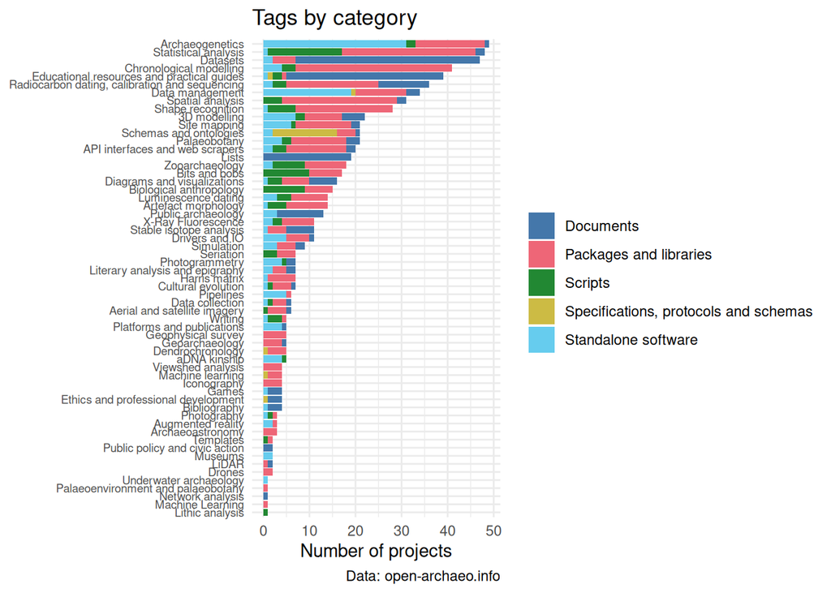

We found that many repositories do not explicitly denote an open source license, or any license at all Table 4.

| License | N |
| --- | --- |
| None detected | 262 |
| GNU General Public License v3.0 | 122 |
| MIT License | 56 |
| Other | 52 |
| GNU General Public License v2.0 | 22 |
| Creative Commons Zero v1.0 Universal | 11 |
| Apache License 2.0 | 8 |
| GNU Affero General Public License v3.0 | 5 |
| BSD 3-Clause "New" or "Revised" License | 3 |
| Creative Commons Attribution 4.0 International | 3 |
| The Unlicense | 3 |
| Creative Commons Attribution Share Alike 4.0 International | 2 |
| Artistic License 2.0 | 1 |
| CeCILL Free Software License Agreement v2.1 | 1 |
| GNU Lesser General Public License v2.1 | 1 |
| Mozilla Public License 2.0 | 1 |

Archaeological software development activity has increased significantly over the years. Figure 2 shows the cumulative growth of code contributions committed and pushed to GitHub repositories, and the number of GitHub repositories that host archaeological software and resources.

[figure not shown]

As we can see, archaeologists have been using git from even before GitHub was launched in 2008. But use of git really began to take off around 2014–2015, when we see an uptick in the rate of growth that has continued ever since.

Around this time we also see that GitHub starts being used to host documents and scripts. This may represent a recognition of GitHub’s ability to track things other than code, and a willingness to experiment with version control systems as a medium for disseminating work in an open and somewhat nerdy way.

- Compare changing proportions of each category on a year by year basis
- Identify temporal trends in the use of licenses

# 5 Collaborative practices

But how is this activity distributed across repositories? In this section we assess projects’ pulse, or the amount of activity pertaining to a repository.

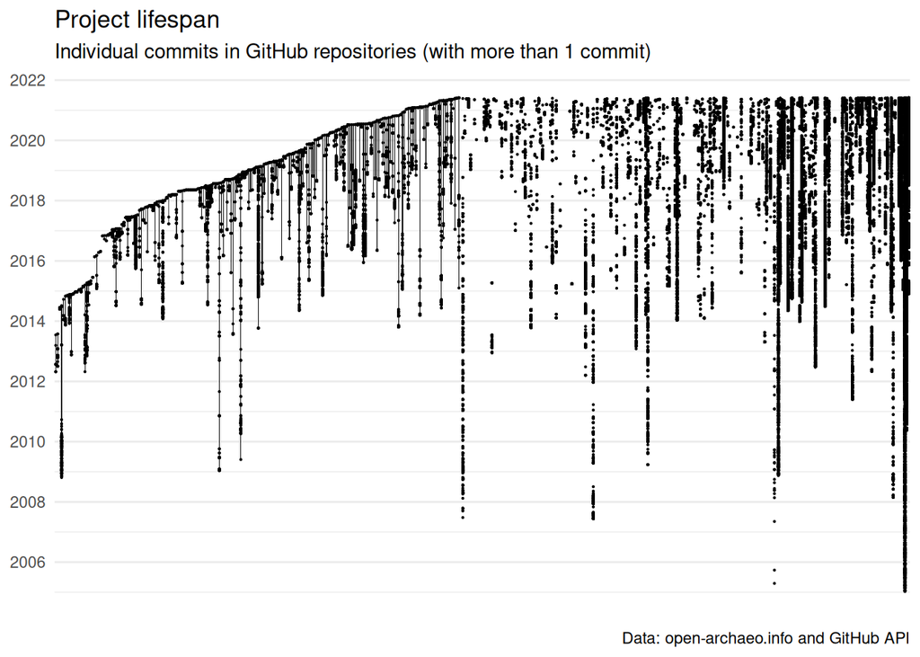

The span of time between the first and latest commits is visualized more clearly in the following charts. Notably, many projects are active for only a short period of time: about 15% less than a month, 25% less than three months, and 40% less than a year. Projects with a short span of activity tend to have very high commit frequency, whereas there is much more variety in long-term projects. Among projects with a greater lifespan, those with more total commits have much more frequent activity than those with fewer total commits, which represent the majority of long-lived projects. The overall negative trend (seen in the top-right graph) can be explained in terms of natural processes, i.e. the only way to fit a high number of commits within the same span as a project with a low number of commits is to commit more frequently. But bearing in mind both axes use a logarithmic scale, the upper left portion of the graph does appear to suggest that short-lived projects are characterised by a spree of rapid committing; while longer-lived projects have a more diverse range of workrates. This latter pattern in turn appears to be explained by the number of contributors: projects that sustain a high commit rate over a long period of time tend to rely on a large number of contributors, as per the bottom-right graph.

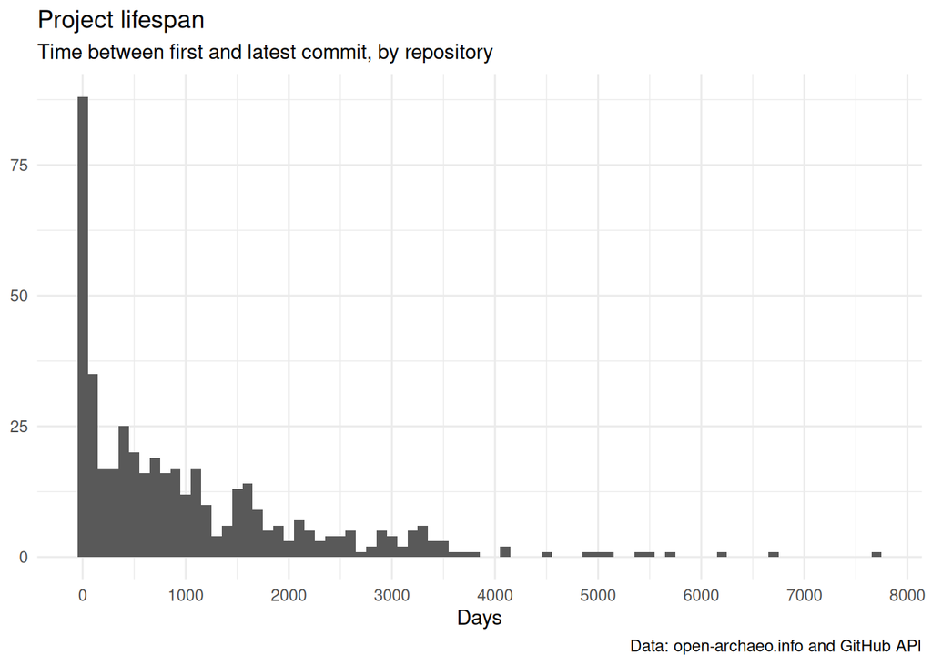

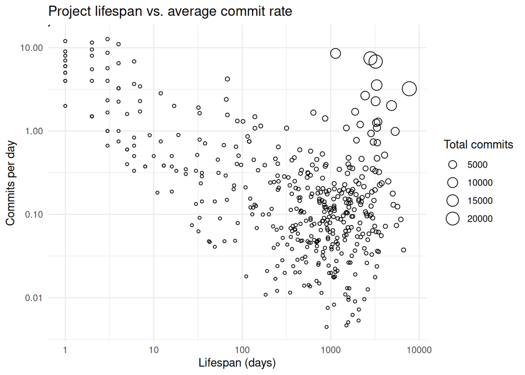

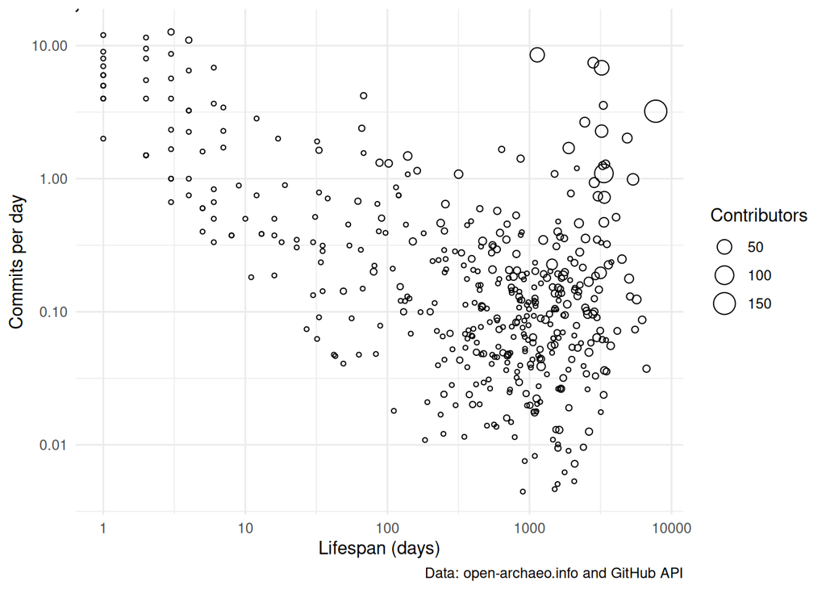

Perhaps unfortunately then, we also find that nearly 60% of projects have only a single contributor, and projects with more than a dozen are very rare indeed [<3%]. A “contribution”, in this case, is a commit, issue, or comment applied by a user to a repository.

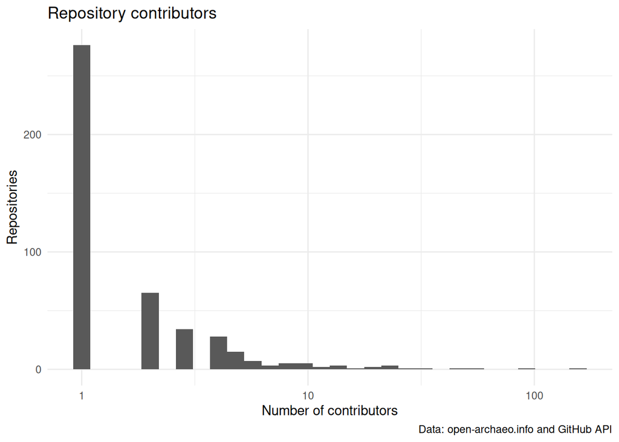

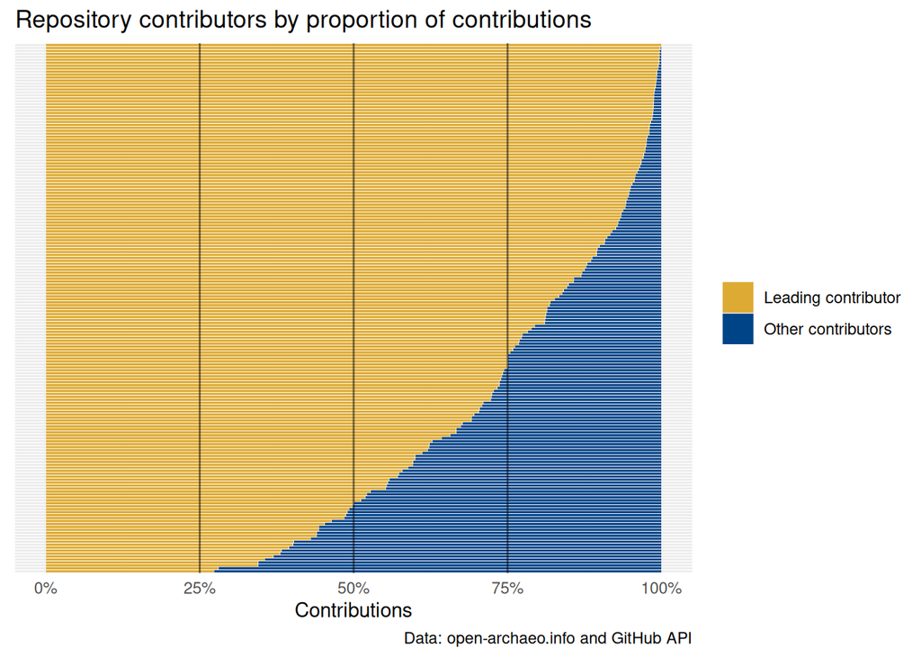

Perhaps as a result of this, we also find that only a minority of projects make much use of collaborative features of GitHub such as issues and pull requests (left) and comments (right). Only 39% of repositories make use of these features. Of these repositories with any issues and pull requests, 28% have only 1 and 82% have less than 10. However, of all repositories that have any comments posted in reply to issues and pull requests, there is actually a significant degree of activity. This seems to suggest that people are willing to respond to issues raised by others, but may not necessarily want to take initiative, for a variety of reasons that may be more effectively investigated through qualitative analysis of the conversations in the issue threads.

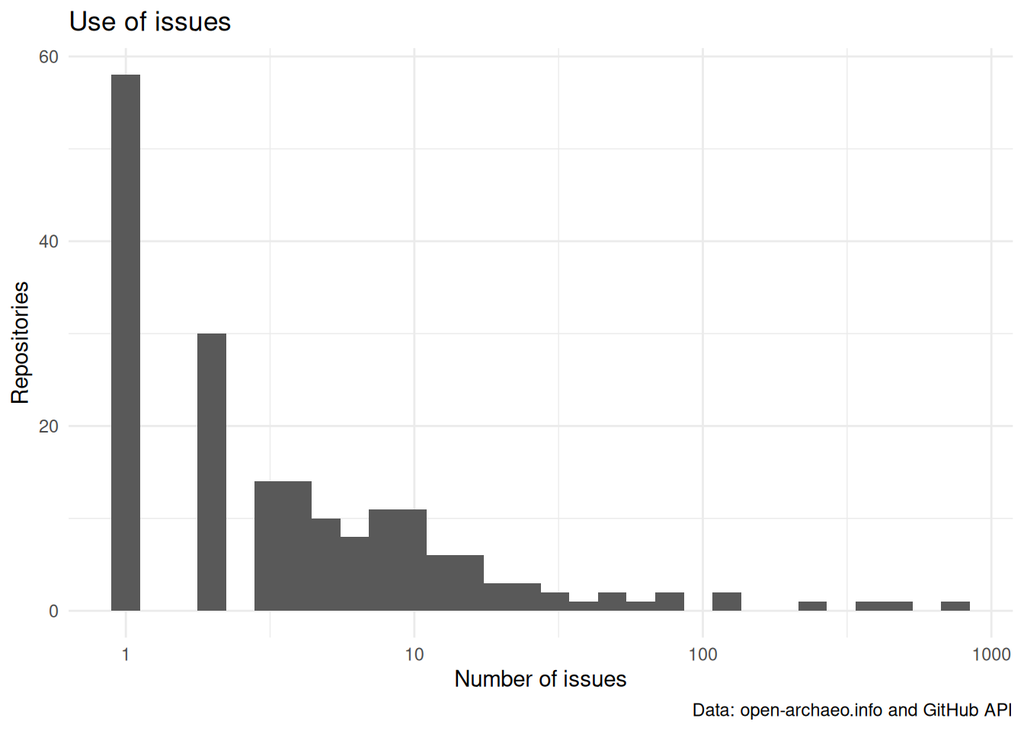

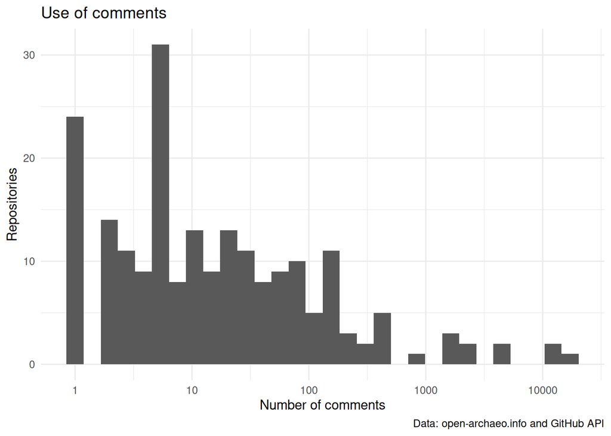

# 6 An emerging community of practice?

We constructed and analyzed networks representing users’ contributions to GitHub repositories to examine the emergence of collaborative tendencies. We sought to identify clusters of repositories that share common sets of contributors, and the different kinds of contributions that draw the network together.

We started by constructing a graph connecting users to the repositories that they contributed to, accounting for commits, issues, and comments as distinct kinds of relations.

We then extracted two one-mode networks from this, one connecting repositories by common users, and the other connecting users by common repositories.

## 6.1 repo-repo

Table 5: Most central repositories in the repository–repository network

| Repository | Betweenness Centrality | Category | Tags | Commits |
| --- | --- | --- | --- | --- |
| zackbatist/open-archaeo | 14205.212 | Lists and datasets | Lists | 323 |
| benmarwick/ctv-archaeology | 5942.980 | Lists and datasets | Lists | 621 |
| ahb108/rcarbon | 3224.430 | Packages and libraries | Radiocarbon dating, calibration and sequencing | 881 |
| ropensci/c14bazAAR | 2954.566 | Packages and libraries | API interfaces and web scrapers | 1031 |
| paleolimbot/tidypaleo | 2447.751 | Packages and libraries | Data management | 168 |
| ISAAKiel/oxcAAR | 2060.417 | Packages and libraries | Radiocarbon dating, calibration and sequencing; Chronological modelling | 246 |
| kacebe/AtlantGIS | 1834.416 | Lists and datasets | Educational resources and practical guides | 122 |
| ropensci/neotoma | 1831.702 | Packages and libraries | API interfaces and web scrapers | 809 |
| alexbrandsen/timeperiod2daterange | 1310.000 | Scripts | Chronological modelling; Bits and bobs | 10 |
| ANGSD/angsd | 1277.257 | Standalone software | Archaeogenetics; Low-coverage contamination estimation | 1571 |

**NOTE:** What happens to this interpretation when we differentiate commits from issues and comments?

## 6.2 user-user

We assembled graphs linking users based on common contributions to the same repositories.

Table 6: Most central users in the user–user network

| User | Centrality | repos | Contributions Own repositories | Contributions Others' repositories |
| --- | --- | --- | --- | --- |
| steko | 413988.7 | 7 | 564 | 26 |
| jfy133 | 368692.0 | 12 | 139 | 7714 |
| clemsciences | 355380.8 | 2 | 0 | 174 |
| TCLamnidis | 235305.2 | 2 | 27 | 171 |
| souravsingh | 200618.4 | 2 | 0 | 22 |
| mfindeisen | 174941.5 | 2 | 0 | 9 |
| willismonroe | 173981.7 | 4 | 65 | 6 |
| zoometh | 134481.0 | 2 | 1078 | 15 |
| zackbatist | 129708.5 | 7 | 457 | 34 |
| gavinsimpson | 127134.4 | 7 | 1122 | 504 |

# 7 Conclusion

Archaeology is a “magpie” discipline, using tools and methods that originate from a variety of other disciplines and industries to better understand the past. Moreover, archaeologists are accustomed to working on shoestring budgets, having to adapt their tools to suit specific, non-generalizable situations, and applying a DIY work ethic to create and co-creating with others to get the job done (Batist et al 2021; Morgan and Eve 2012; Caraher 2019). It is therefore unsprising that archaeologists are prolific open source software developers.

These caveats notwithstanding, we have documented that open source software development in archaeology has seen a rapid and sustained rise beginning around 2014. This is marked by a variety of applications and use cases, including the use of git and GitHub to track and host content other than code. Moreover, archaeologists are very involved in broader scripting ecosystems, as is evident through the predominant creation of R packages and Python libraries designed to process the rich variety of archaeological information. At the same time, archaeologists also create standalone software for more intensive tasks that require greater access to system resources or that warrant more complex user interfaces than what R and Python IDEs are capable of providing.

Looking at the distribution of tags, we note that, among items listed as software, repositories tend to be focused on various means of identifying distribution patterns (spatial, temporal, statistical), calibrating data obtained from various instrumental methods (XRF, luminescence dating), supporting specialized finds analysis (zooarchaeology, palaeobotany, archaeogenetics), and supporting the collection and processing of archaeological materials. These foci signify gaps in the archaeological toolbox that archaeologists recognized, and have attempted to fill, on their own terms. In future studies, it would be interesting to examine how the purposeful expansion of open source tools corresponds with broader methodological trends apparent in publishing patterns or through other expressions of archaeological interest (e.g. social media posts, conference sessions).

However, we seem to have entered a period of critical reflection on the practical ramifications of infrastructures developed to support open science. For instance, Huggett (2022) identified social frictions as a necessary aspect of productive research, which open science infrastructures effectively seek to eliminate. Numerous other studies by Batist (2023), Huvila (2022), Haciguzeller et al. (2021), Opitz et al. (2021) Sobotkova (2018), Wylie (2017) Atici et al. (2013), Faniel et al. (2013) (among others) highlighted the need to account for the work involved in preparing and making use of materials shared openly on the web, and which are effectively muted by infrastructures developed in pursuit of open science.

## References

Atici, Levent, Sarah Whitcher Kansa, Justin Lev-Tov, and Eric C. Kansa. 2013. “Other People’s Data: A Demonstration of the Imperative of Publishing Primary Data.” *Journal of Archaeological Method and Theory* 20 (4): 663. https://doi.org/10.1007/s10816-012-9132-9.

Batist, Zachary, and Joe Roe. 2023. “Open-Archaeo: A Resource for Documenting Archaeological Software Development Practices.” *Journal of Open Archaeology Data* 11 (0): 9. https://doi.org/10.5334/joad.111.

Baxter, Rob, N. Chue Hong, Dirk Gorissen, James Hetherington, and Ilian Todorov. 2012. “The Research Software Engineer.” In *Digital Research Conference, Oxford*, 1–3.

Beck, Anthony, and Cameron Neylon. 2012. “A Vision for Open Archaeology.” *World Archaeology* 44 (4): 479–97. https://doi.org/10.1080/00438243.2012.737581.

Coleman, E. Gabriella. 2012. *Coding Freedom: The Ethics and Aesthetics of Hacking*. Princeton University Press. https://doi.org/10.1515/9781400845293.

Cowgill, George L. 1967. “Computer Applications in Archaeology.” In *Proceedings of the November 14-16, 1967, Fall Joint Computer Conference*, 331–37. AFIPS ’67 (Fall). New York, NY, USA: Association for Computing Machinery. https://doi.org/10.1145/1465611.1465654.

Csárdi, Gábor, Jennifer Bryan, Hadley Wickham, and RStudio. 2023. “Gh: ’GitHub’ ’API’.”

Faniel, Ixchel, Eric C. Kansa, Sarah Whitcher Kansa, Julianna Barrera-Gomez, and Elizabeth Yakel. 2013. “The Challenges of Digging Data: A Study of Context in Archaeological Data Reuse.” In *Proceedings of the 13th ACM/IEEE-CS Joint Conference on Digital Libraries*, 295–304. New York: ACM. https://doi.org/10.1145/2467696.2467712.

Huggett, Jeremy. 2018. “Reuse Remix Recycle: Repurposing Archaeological Digital Data.” *Advances in Archaeological Practice* 6 (2): 93–104. https://doi.org/10.1017/aap.2018.1.

Kansa, Eric C., Sarah Whitcher Kansa, and Benjamin Arbuckle. 2014. “Publishing and Pushing: Mixing Models for Communicating Research Data in Archaeology.” *International Journal of Digital Curation* 9 (1): 57–70. https://doi.org/10.2218/ijdc.v9i1.301.

Kelty, Christopher M. 2008. *Two Bits: The Cultural Significance of Free Software*. Duke University Press.

Kintigh, Keith W., Jeffrey H. Altschul, Ann P. Kinzig, W. Fredrick Limp, William K. Michener, Jeremy A. Sabloff, Edward J. Hackett, Timothy A. Kohler, Bertram Ludäscher, and Clifford A. Lynch. 2015. “Cultural Dynamics, Deep Time, and Data: Planning Cyberinfrastructure Investments for Archaeology.” *Advances in Archaeological Practice* 3 (1): 1–15. https://doi.org/10.7183/2326-3768.3.1.1.

Lai, Jiangshan, Christopher J. Lortie, Robert A. Muenchen, Jian Yang, and Keping Ma. 2019. “Evaluating the Popularity of R in Ecology.” *Ecosphere* 10 (1): e02567. https://doi.org/10.1002/ecs2.2567.

Marwick, Ben, Jade d’Alpoim Guedes, C. Michael Barton, Lynsey A. Bates, Michael Baxter, Andrew Bevan, Elizabeth A. Bollwerk, R. Kyle Bocinsky, Tom Brughmans, and Alison K. Carter. 2017. “Open Science in Archaeology.” *SAA Archaeological Record* 17 (4): 8–14.

Mirowski, Philip. 2018. “The Future (s) of Open Science.” *Social Studies of Science* 48 (2): 171–203. https://doi.org/10.1177/0306312718772086.

O’Neil, Mathieu. 2009. *Cyberchiefs: Autonomy and Authority in Online Tribes*. London, UK: Pluto Press.

Open Knowledge Foundation. 2023. “Open Definition 2.1.” https://opendefinition.org/od/2.1/en/.

Open Source Initiative. 2007. “The Open Source Definition.” https://opensource.org/osd/.

Opitz, Rachel, Colleen Strawhacker, Philip Buckland, Jackson Cothren, Tom Dawson, Andrew Dugmore, George Hambrecht, et al. 2021. “A Lockpick’s Guide to dataARC: Designing Infrastructures and Building Communities to Enable Transdisciplinary Research.” *Internet Archaeology*, no. 56 (October). https://doi.org/10.11141/ia.56.15.

Roosevelt, Christopher H., Peter Cobb, Emanuel Moss, Brandon R. Olson, and Sinan Ünlüsoy. 2015. “Excavation Is Destruction Digitization: Advances in Archaeological Practice.” *Journal of Field Archaeology* 40 (3): 325–46. https://doi.org/10.1179/2042458215Y.0000000004.

Schmidt, Sophie C, and Ben Marwick. 2020. “Tool-Driven Revolutions in Archaeological Science.” *Journal of Computer Applications in Archaeology* 3 (1): 18–32. https://doi.org/10.5334/jcaa.29.

Scollar, Irwin. 1999. “25 Years of Computer Applications in Archaeology.” In *Archaeology in the Age of the Internet. CAA97: Computer Applications and Quantitative Methods in Archaeology, Proceedings of the 25th Anniversary Conference, University of Birmingham, April 1997*, edited by L. Dingwall, S. Exon, V. Gaffney, S. Laflin, and M. van Leusen, 5–10. BAR International Series 750.

Sobotkova, Adela. 2018. “Sociotechnical Obstacles to Archaeological Data Reuse.” *Advances in Archaeological Practice* 6 (2): 117–24. https://doi.org/10.1017/aap.2017.37.

Tennant, Jonathan, Ritwik Agarwal, Ksenija Baždarić, David Brassard, Tom Crick, Daniel J. Dunleavy, Thomas Rhys Evans, et al. 2020. “A Tale of Two ’Opens’: Intersections Between Free and Open Source Software and Open Scholarship.” SocArXiv. https://doi.org/10.31235/osf.io/2kxq8.